# Splines

```r
library(ISLR)
attach(Wage)
```

## Cubic Spline

**bs function**

bs function generates a matrix of basis functions for splines with specified set of knots. By default, it produces cubic spline. We will try to fit wage to age.

```r
library(splines)
age.range <- range(age)
age.grid <- seq(from = age.range[1], to = age.range[2])
fit1 <- lm(wage ~ bs(age, knots = c(25, 40, 60)), data = Wage)
pred <- predict(fit1, newdata = list(age=age.grid), se = TRUE)
plot(age, wage, col = 'gray')
lines(age.grid, pred$fit, lwd = '3', col = 'blue')
```

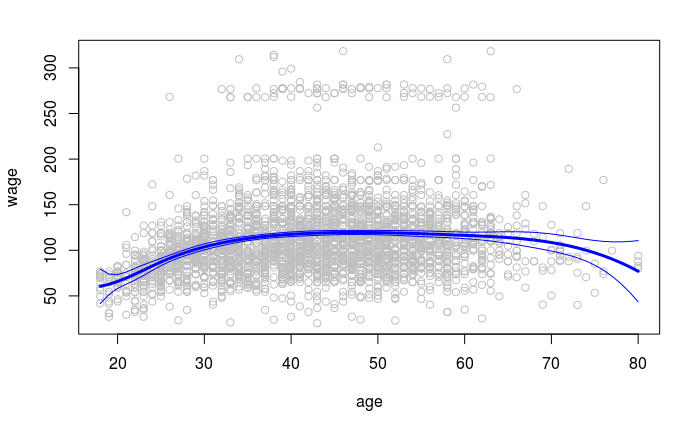

```r
lines(age.grid, pred$fit + 2*pred$se, col = 'blue')
lines(age.grid, pred$fit - 2*pred$se, col = 'blue')
```

Cubic spline with three knots has 7 degrees of freedom; one is used by intercept and other six are used by six basis functions.

**df() option:**

We can also use df option to produce a spline with knots at uniform quantiles.

```r
dim(bs(age, knots = c(25, 40, 60)))
```

```
[1] 3000    6
```

```r
dim(bs(age, df=6))
```

```
[1] 3000    6
```

```r
attr(bs(age, df=6), 'knots')
```

```
  25%   50%   75%
33.75 42.00 51.00
```

Here, knots are 25th, 50th and 75th quantiles. bs() also has degree option. Thus, we can fit splines of any degree instead of default degree 3.

## Natural Splines

**ns() function**:

For natural splines we can use ns function. Here we are fitting age to age using natural splines with 4 degrees of freedom

```r
attr(ns(age, df=4), 'knots')
```

```
  25%   50%   75%
33.75 42.00 51.00
```

```r
fit2 <- lm(wage ~ ns(age, df=4), data = Wage)
pred2 <- predict(fit2, newdata = list(age=age.grid), se = T)
plot(age, wage, col = 'gray')
lines(age.grid, pred2$fit, lwd = 3)
```

```r
lines(age.grid, pred2$fit + 2*pred$se, lty = 'dashed')
lines(age.grid, pred2$fit - 2*pred$se, lty = 'dashed')
```

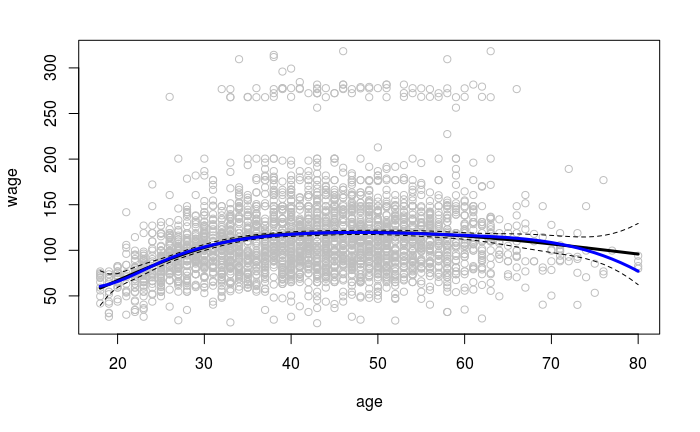

```r
lines(age.grid, pred$fit, lwd = 3, col = 'blue')
```

## Smoothing Splines

```r
plot(age, wage, cex = 0.5, col = "darkgrey")
title('Smoothing Splines')
```

```r
fit3 <- smooth.spline(age, wage, df = 16)
fit4 <- smooth.spline(age, wage, cv = TRUE)
```

```
cross-validation with non-unique 'x' values seems doubtful
```

```r
fit4$df
```

```
[1] 6.794596
```

```r
lines(fit3, col = 'red', lwd = 2)
lines(fit4, col = 'blue', lwd = 2)
```

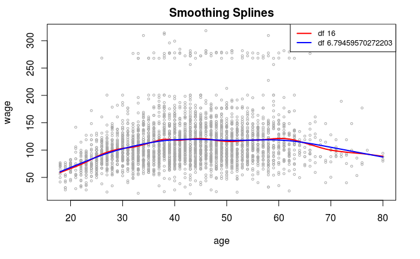

```r
legend("topright", legend = c("df 16", paste("df", toString(fit4$df), sep = " ")), col = c("red", "blue"), lty = 1, lwd = 2, cex = .8)
```

1. In first we have df = 16, so **smooth.spline()** selects value of *lambda* that leads to 16 degrees of freedom.
2. In second we did cross validation which results in df = 6.8. **smooth.spline()** chooses a value of *lambda* that leads to 6.8 degrees of freedom.

## Local Regression

```r
plot(age, wage, cex = 0.5, col = 'darkgray')
fit5 <- loess(wage~age, span = 0.2, data=Wage)
fit6 <- loess(wage~age, span = 0.5, data=Wage)
lines(age.grid, predict(fit5, data.frame(age=age.grid)), col = "red", lwd=3)
```

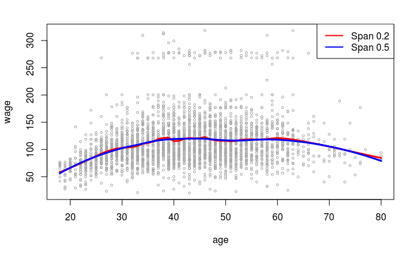

```r
lines(age.grid, predict(fit6, data.frame(age=age.grid)), col = "blue", lwd=3)
legend("topright", legend = c("Span 0.2", "Span 0.5"), col=c("red", "blue"), lty = 1, lwd =2, cex = 1.0)
```

Span of 0.2 and 0.5 means 20% and 50% of observations are considered as neighbors. **locfit** is also available to find local regression in R.